# SDM - ASSIGN - 2

```r
setwd("~/Desktop/R Assignment - JupR -2")
```

```r
library(ISLR)
library(caret)
library(tidyverse)
```

```r
college <- data.frame(College)
```

```r
data('College')
```

```r
head(College)
```

A data.frame: 6 × 18

|  | Private <fct> | Apps <dbl> | Accept <dbl> | Enroll <dbl> | Top10perc <dbl> | Top25perc <dbl> | F.Undergrad <dbl> | P.Undergrad <dbl> | Outstate <dbl> | Room.Board <dbl> | Books <dbl> | Personal <dbl> | PhD <dbl> | Terminal <dbl> | S.F.Ratio <dbl> | perc.alumni <dbl> | Expend <dbl> | Grad.Rate <dbl> |
| --- | --- | --- | --- | --- | --- | --- | --- | --- | --- | --- | --- | --- | --- | --- | --- | --- | --- | --- |
| Abilene Christian University | Yes | 1660 | 1232 | 721 | 23 | 52 | 2885 | 537 | 7440 | 3300 | 450 | 2200 | 70 | 78 | 18.1 | 12 | 7041 | 60 |
| Adelphi University | Yes | 2186 | 1924 | 512 | 16 | 29 | 2683 | 1227 | 12280 | 6450 | 750 | 1500 | 29 | 30 | 12.2 | 16 | 10527 | 56 |
| Adrian College | Yes | 1428 | 1097 | 336 | 22 | 50 | 1036 | 99 | 11250 | 3750 | 400 | 1165 | 53 | 66 | 12.9 | 30 | 8735 | 54 |
| Agnes Scott College | Yes | 417 | 349 | 137 | 60 | 89 | 510 | 63 | 12960 | 5450 | 450 | 875 | 92 | 97 | 7.7 | 37 | 19016 | 59 |
| Alaska Pacific University | Yes | 193 | 146 | 55 | 16 | 44 | 249 | 869 | 7560 | 4120 | 800 | 1500 | 76 | 72 | 11.9 | 2 | 10922 | 15 |
| Albertson College | Yes | 587 | 479 | 158 | 38 | 62 | 678 | 41 | 13500 | 3335 | 500 | 675 | 67 | 73 | 9.4 | 11 | 9727 | 55 |

```r
dim(College)
```

1. 777

2. 18

```r
str(College)
```

```
'data.frame':	777 obs. of  18 variables:
 $ Private    : Factor w/ 2 levels "No","Yes": 2 2 2 2 2 2 2 2 2 2 ...
 $ Apps       : num  1660 2186 1428 417 193 ...
 $ Accept     : num  1232 1924 1097 349 146 ...
 $ Enroll     : num  721 512 336 137 55 158 103 489 227 172 ...
 $ Top10perc  : num  23 16 22 60 16 38 17 37 30 21 ...
 $ Top25perc  : num  52 29 50 89 44 62 45 68 63 44 ...
 $ F.Undergrad: num  2885 2683 1036 510 249 ...
 $ P.Undergrad: num  537 1227 99 63 869 ...
 $ Outstate   : num  7440 12280 11250 12960 7560 ...
 $ Room.Board : num  3300 6450 3750 5450 4120 ...
 $ Books      : num  450 750 400 450 800 500 500 450 300 660 ...
 $ Personal   : num  2200 1500 1165 875 1500 ...
 $ PhD        : num  70 29 53 92 76 67 90 89 79 40 ...
 $ Terminal   : num  78 30 66 97 72 73 93 100 84 41 ...
 $ S.F.Ratio  : num  18.1 12.2 12.9 7.7 11.9 9.4 11.5 13.7 11.3 11.5 ...
 $ perc.alumni: num  12 16 30 37 2 11 26 37 23 15 ...
 $ Expend     : num  7041 10527 8735 19016 10922 ...
 $ Grad.Rate  : num  60 56 54 59 15 55 63 73 80 52 ...
```

```r
ncol(College)
```

18

```r
colnames(College)
```

1. 'Private'

2. 'Apps'

3. 'Accept'

4. 'Enroll'

5. 'Top10perc'

6. 'Top25perc'

7. 'F.Undergrad'

8. 'P.Undergrad'

9. 'Outstate'

10. 'Room.Board'

11. 'Books'

12. 'Personal'

13. 'PhD'

14. 'Terminal'

15. 'S.F.Ratio'

16. 'perc.alumni'

17. 'Expend'

18. 'Grad.Rate'

## Q1(a) - Split the data set into a training set and a test set. Fit a linear model using least squares on the training set, and report the test error obtained.

```r
set.seed(37)
```

```r
randomsplit <- createDataPartition(College$Apps, p = 0.80, list = FALSE)
```

```r
train <- College[randomsplit,]
test <- College[-randomsplit,]
```

```r
prep <- preProcess(train, method = c('center', 'scale'))
```

```r
train <- predict(prep, train)
test <- predict(prep, test)
```

```r
dim(train)
dim(test)
```

1. 624

2. 18

1. 153

2. 18

```r
head(train)
head(test)
```

A data.frame: 6 × 18

|  | Private <fct> | Apps <dbl> | Accept <dbl> | Enroll <dbl> | Top10perc <dbl> | Top25perc <dbl> | F.Undergrad <dbl> | P.Undergrad <dbl> | Outstate <dbl> | Room.Board <dbl> | Books <dbl> | Personal <dbl> | PhD <dbl> | Terminal <dbl> | S.F.Ratio <dbl> | perc.alumni <dbl> | Expend <dbl> | Grad.Rate <dbl> |
| --- | --- | --- | --- | --- | --- | --- | --- | --- | --- | --- | --- | --- | --- | --- | --- | --- | --- | --- |
| Adelphi University | Yes | -0.2113982 | -0.04572629 | -0.2911582 | -0.6640834 | -1.3547335 | -0.2199422 | 0.2414575 | 0.4561904 | 1.91371630 | 1.1314252 | 0.2383086 | -2.6512990 | -3.3987382 | -0.5037707 | -0.557604347 | 0.21159458 | -0.5671311 |
| Adrian College | Yes | -0.3999240 | -0.36855014 | -0.4732139 | -0.3261691 | -0.2952160 | -0.5460728 | -0.4839935 | 0.1978842 | -0.53538086 | -0.8642271 | -0.2600218 | -1.1960334 | -0.9299552 | -0.3123144 | 0.570552670 | -0.17423030 | -0.6861096 |
| Agnes Scott College | Yes | -0.6513747 | -0.66053592 | -0.6790609 | 1.8139546 | 1.6724594 | -0.6502287 | -0.5071462 | 0.6267226 | 1.00664328 | -0.5791339 | -0.6914123 | 1.1687731 | 1.1959413 | -1.7345607 | 1.134631178 | 2.03931077 | -0.3886632 |
| Albertson College | Yes | -0.6090932 | -0.60978973 | -0.6573383 | 0.5749356 | 0.3102226 | -0.6169622 | -0.5212951 | 0.7621452 | -0.91181616 | -0.2940407 | -0.9889229 | -0.3471285 | -0.4499140 | -1.2695956 | -0.960517568 | 0.03935133 | -0.6266203 |
| Albertus Magnus College | Yes | -0.6672924 | -0.66404912 | -0.7142307 | -0.6077643 | -0.5474821 | -0.6688421 | -0.3997435 | 0.7094808 | 1.25155299 | -0.2940407 | 0.2383086 | 1.0475010 | 0.9216321 | -0.6952269 | 0.248222093 | -0.14710199 | -0.1507062 |
| Albright College | Yes | -0.4969228 | -0.46926182 | -0.5859642 | 0.1243833 | 0.3606758 | -0.5585478 | -0.3508656 | 1.2875349 | 0.05421661 | -1.4344135 | -1.2492448 | 0.3805043 | 0.3044364 | -0.7499287 | 0.006474161 | 0.45208922 | 0.8606115 |

A data.frame: 6 × 18

|  | Private <fct> | Apps <dbl> | Accept <dbl> | Enroll <dbl> | Top10perc <dbl> | Top25perc <dbl> | F.Undergrad <dbl> | P.Undergrad <dbl> | Outstate <dbl> | Room.Board <dbl> | Books <dbl> | Personal <dbl> | PhD <dbl> | Terminal <dbl> | S.F.Ratio <dbl> | perc.alumni <dbl> | Expend <dbl> | Grad.Rate <dbl> |
| --- | --- | --- | --- | --- | --- | --- | --- | --- | --- | --- | --- | --- | --- | --- | --- | --- | --- | --- |
| Abilene Christian University | Yes | -0.3422222 | -0.3158522 | -0.07496711 | -0.2698501 | -0.1943096 | -0.1799431 | -0.20230244 | -0.757597672 | -0.9435637 | -0.5791339 | 1.2795959 | -0.1652203 | -0.1070275 | 1.10993183 | -0.8799349 | -0.53895539 | -0.3291740 |
| Alaska Pacific University | Yes | -0.7070868 | -0.7397781 | -0.76388226 | -0.6640834 | -0.5979353 | -0.7019106 | 0.01121685 | -0.727503754 | -0.1997638 | 1.4165184 | 0.2383086 | 0.1985961 | -0.5184913 | -0.58582333 | -1.6857614 | 0.29663968 | -3.0061912 |
| Albion College | Yes | -0.2827794 | -0.1253588 | -0.31494956 | 0.5186166 | 0.6129419 | -0.4355805 | -0.52708328 | 0.854433213 | 0.4406297 | -0.5791339 | -0.7286011 | 0.9868649 | 1.4016733 | -0.09350731 | 1.1346312 | 0.41828648 | 0.4441866 |
| Alderson-Broaddus College | Yes | -0.6103368 | -0.6023730 | -0.64285662 | -0.3824881 | -0.5979353 | -0.5930024 | -0.49749929 | 0.001772197 | -0.8709979 | 0.6182575 | 0.6845746 | -1.9843023 | -2.6443879 | -0.69522689 | -0.6381870 | -0.11911246 | -0.8050882 |
| Alma College | Yes | -0.4399671 | -0.3751862 | -0.42252790 | 0.9128499 | 0.8652079 | -0.4926088 | -0.52965580 | 0.529418897 | 0.1920917 | -0.8642271 | -1.3980001 | 0.3805043 | 0.5101683 | 0.34410692 | 0.7317180 | -0.05150699 | 0.1467402 |
| Amherst College | Yes | 0.3148823 | -0.4095375 | -0.38839247 | 3.1092927 | 2.0256318 | -0.4357785 | -0.54444780 | 2.332044597 | 0.8705823 | 0.6182575 | 0.3840888 | 1.2294092 | 1.2645187 | -1.54310446 | 3.2297799 | 2.55776295 | 2.0503969 |

```r
train.y <- train$Apps
test.y <- test$Apps
head(train.y,15)
head(test.y)
```

1. -0.365651423516162

2. -0.430270621394508

3. -0.711865488010921

4. -0.664515213703512

5. -0.299082508460452

6. -0.345597189691847

7. -0.0893486463811651

8. -0.499624846703594

9. -0.475114116473877

10. -0.690418599059918

11. 0.370227545426037

12. -0.4893191987661

13. 0.157986904118711

14. 1.20888446271785

15. 2.73969097797384

1. -0.219144104188532

2. -0.774256437686565

3. -0.729691473632533

4. -0.53889772127621

5. -0.6659078688302

6. -0.432498869597209

```r
ony_encoding <- dummyVars(Apps ~ ., data = train)
ony_encoding
train.x <- predict(ony_encoding, train)
test.x <- predict(ony_encoding, test)
```

```
Dummy Variable Object

Formula: Apps ~ .
18 variables, 1 factors
Variables and levels will be separated by '.'
A less than full rank encoding is used
```

```r
head(train.x)
head(test.x)
```

A matrix: 6 × 18 of type dbl

[output not shown]

A matrix: 6 × 18 of type dbl

[output not shown]

```r
linear_m <- lm(Apps ~ ., data = train)
lin_predic <- predict(linear_m, test)
(linear_i <- postResample(lin_predic, test$Apps))

lin_MSE <- mean((lin_predic - test$Apps)^2); lin_MSE
```

**RMSE**

0.364547534845911

**Rsquared**

0.945475916643081

**MAE**

0.164703290348797

0.132894905162231

## Q1(b) Fit a ridge regression model on the training set, with lam chosen by crossvalidation. Report the test error obtained.

```r
install.packages("glmnet")
```

```r
rid_fit <- train(x = train.x, y = train.y,
                   method = 'glmnet',
                   trControl = trainControl(method = 'cv', number = 10),
                   tuneGrid = expand.grid(alpha = 0,
                                          lambda = seq(0, 10e2, length.out = 20)))
```

```r
(rid_info <- postResample(predict(rid_fit, test.x), test.y))
```

**RMSE**

0.528193813099325

**Rsquared**

0.8880963481496

**MAE**

0.198599760182684

```r
coef(rid_fit$finalModel, rid_fit$bestTune$lambda)
```

```
19 x 1 sparse Matrix of class "dgCMatrix"
                      s1
(Intercept)  0.047287585
Private.No   0.100217000
Private.Yes -0.101189699
Accept       0.509377616
Enroll       0.161105772
Top10perc    0.131469933
Top25perc    0.006317287
F.Undergrad  0.141952374
P.Undergrad  0.011767879
Outstate     0.005151944
Room.Board   0.058989055
Books        0.006388053
Personal    -0.007106430
PhD         -0.015872793
Terminal    -0.020029030
S.F.Ratio    0.015673931
perc.alumni -0.048138534
Expend       0.117828719
Grad.Rate    0.058108322
```

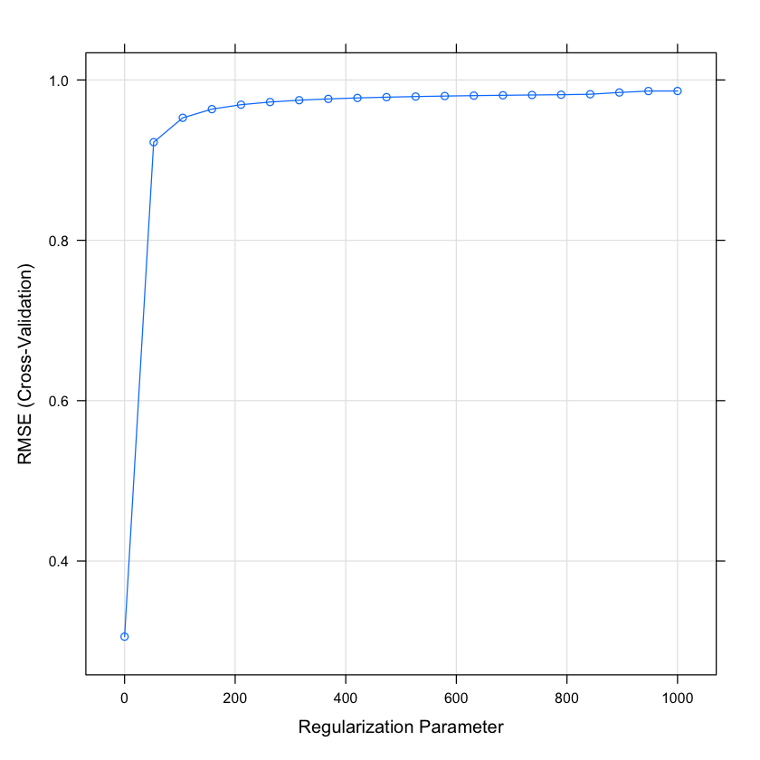

```r
plot(ridge_fit)
```

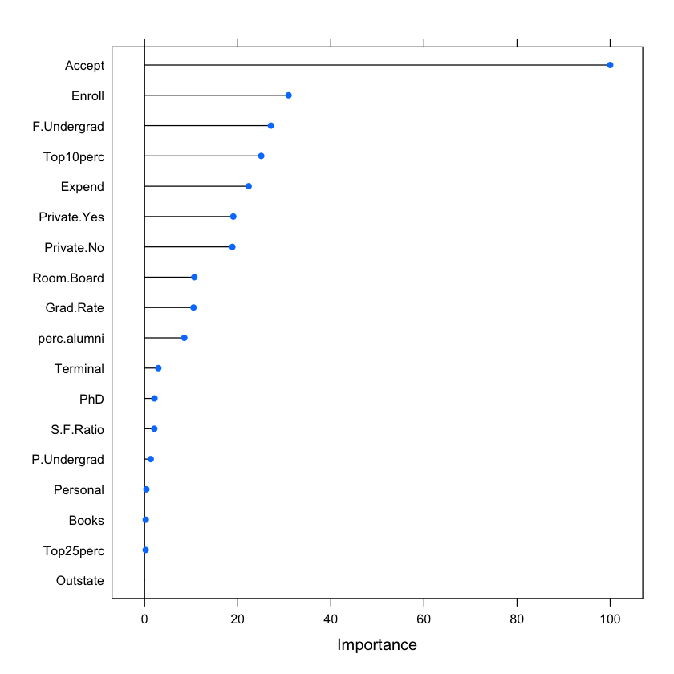

```r
plot(varImp(ridge_fit))
```

## Q1(d) Fit a lasso model on the training set, with lam chosen by cross-validation. Report the test error obtained, along with the number of non-zero coefficient estimates.

```r
las_fit <- train(x = train.x, y = train.y,
                   method = 'glmnet',
                   trControl = trainControl(method = 'cv', number = 10),
                   tuneGrid = expand.grid(alpha = 1,
                                          lambda = seq(0.0001, 1, length.out = 50)))
```

```r
(las_info <- postResample(predict(las_fit, test.x), test.y))
```

**RMSE**

0.368045045486735

**Rsquared**

0.944918321637585

**MAE**

0.16418104707513

```r
coef(las_fit$finalModel, las_fit$bestTune$lambda)
```

```
19 x 1 sparse Matrix of class "dgCMatrix"
                       s1
(Intercept) -4.602356e-02
Private.No   1.719683e-01
Private.Yes -3.736929e-14
Accept       8.156559e-01
Enroll      -7.992584e-02
Top10perc    2.324004e-01
Top25perc   -7.148602e-02
F.Undergrad  1.180751e-01
P.Undergrad  1.216737e-02
Outstate    -4.823323e-02
Room.Board   4.868812e-02
Books        1.557381e-03
Personal     .
PhD         -3.820240e-02
Terminal    -1.370517e-02
S.F.Ratio    1.949270e-02
perc.alumni -2.275036e-02
Expend       1.175063e-01
Grad.Rate    5.240594e-02
```

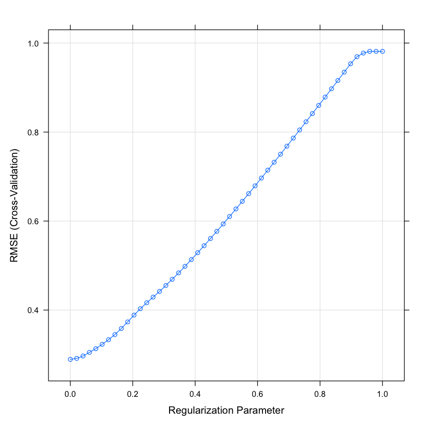

```r
plot(las_fit)
```

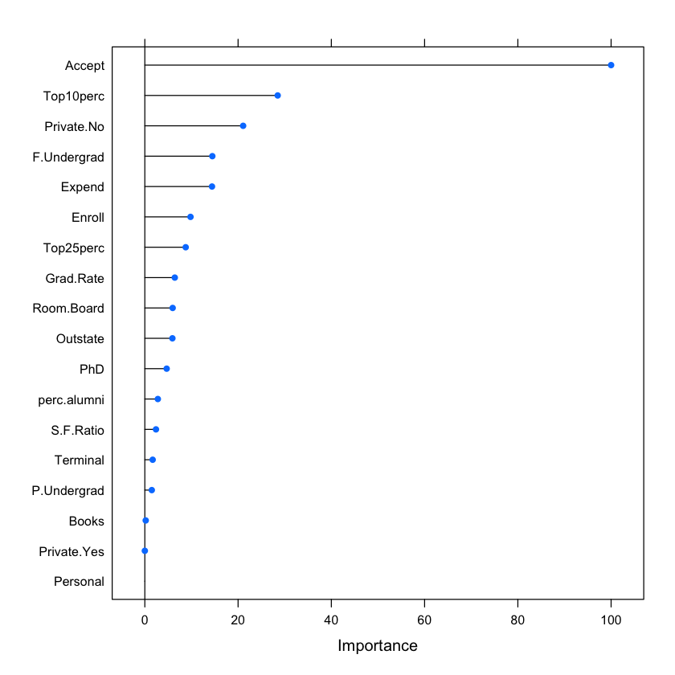

```r
plot(varImp(las_fit))
```